# A quick introduction to Jupyter notebooks

When coding in Python, a standard approach is to create your code in a desktop top IDE and save it as a `.py` file. To improve the readability of your code, you can add comments and docstrings that document the program's behavior. There are two drawbacks to this approach:

- Displaying the graphical output of your program requires opening a new window. On the desktop, this operation is easy. However, in a cloud-based environment, opening a new window on your desktop is often difficult.
- Using plain text to document your code lacks the expressiveness of more modern tools such as HTML. For example, adding something as simple as a subscript/superscript to variable is impossible in plain text.

Jupyter notebooks provide a seamless combination of Python code and Markdown, a lightweight markup language. Jupyter notebooks consist of a sequence of cells of two types, code cells and markdown cells. Text entered into code cells is treated as code. To run the code in single code cell, select cell with your mouse and hit shift+Enter. To run the code in an entire notebook, select the "Run all" command from the "Cell" menu.

In markdown cells, formatted text can be entered as plain text that incorporates Markdown commands. To view the formatted text, you hit shift+Enter in the markdown cell. To view the original Markdown text for a cell, you can simply double click in the cell. **Try double clicking on this cell!**

```python
# This is a code cell.

# Select this cell with your mouse and hit "shift+Enter"

print("Just ran a code cell")
```

[output not shown]

## 2D plots using matplotlib in Jupyter notebooks

In the previous example, the output of the code cell was displayed right below the cell. We can also create examples that produce graphical output. Run this [example code](https://matplotlib.org/users/pyplot_tutorial.html) from the matplotlib tutorial in the code cell below:

```python
# Code cell with a simple example using matplolib and numpy

import numpy as np
import matplotlib.pyplot as plt
```

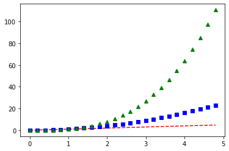

```python
# evenly sampled time at 200ms intervals
t = np.arange(0., 5., 0.2)

# red dashes, blue squares and green triangles
plt.figure()
plt.plot(t, t, 'r--', t, t**2, 'bs', t, t**3, 'g^')
plt.show()
```

## 3D plots using plotly in Jupyter notebooks

Since matplotlib is not design for 3D visualization, we will produce our 3D visualization using [plotly](https://plot.ly/python/). If you are using Anaconda to run this notebook, plotly is not automatically installed with your python installation. Therefore, you need to follow below steps to install plotly package:

```
1. Open “Anaconda Prompt”
2. Type: conda install plotly
3. When asked for Proceed  ([Y]/N)? type: y
4. plotly should now be installed, and you can import it in the cell below.
```

The cell below contains a simplified version of the code for a 3D scatter plot in plotly. Click in the cell and hit shift+Enter to run the code cell. The output of this code cell is a 3D plot that we can rotate/zoom using the mouse.

```python
import plotly.graph_objects as go
import numpy as np

x1, y1, z1 = np.random.multivariate_normal(np.array([0,0,0]), np.eye(3), 200).transpose()
trace0 = go.Scatter3d(x=x1, y=y1, z=z1, mode='markers')

x2, y2, z2 = np.random.multivariate_normal(np.array([0,0,0]), np.eye(3), 200).transpose()
trace1 = go.Scatter3d(x=x2, y=y2, z=z2, mode='markers')

layout = go.Layout(margin=dict(l=0, r=0, b=0, t=0))
fig = go.Figure(data=[trace0, trace1], layout=layout)

fig.show()
#fig.write_to_html("3Dscatter.html")
```

[interactive chart not shown]

## Weekly projects using Jupyter notebooks

From week 3 onward, the weekly projects will entail coding various visualizations using matplotlib and/or plotly inside a Jupyter notebook that we will provide. This notebook will have a name of the form `projectX_template.ipynb`. Your task will be to add code to this notebook that produces the desired visualizations and save the notebook as `projectX_solution.ipynb`.

When your solution notebook is completed, you may submit this notebook for machine-grading. Our grading script will automatically extract the Python code from this notebook, save the result as `projectX_solution.py`, and test each required function for correctness. The grading script will then report back a grade for your project as well as a summary of any errors. You may submit as many times as desired. The machine grade for your **last** submission before the deadline will be your final machine grade.

The plots in the final submitted version of your project notebook will also be graded by your peers after the deadline according to a provided rubric. For some weeks' projects, you will also be asked a few thought questions concering the data analysis done in project. These answers should be entered in the markdown cells provided in the notebook. To aid you in formatting your answer more effectively, we suggest that you review this quick summary of the available [Markdown commands](https://jupyter-notebook.readthedocs.io/en/stable/examples/Notebook/Working%20With%20Markdown%20Cells.html).